# Backtest "portfólios dourados"

**@author=[Jairo da Silva Freitas Júnior](https://www.linkedin.com/in/jairofreitas)**

Neste estudo comparou-se o desempenho de juros e ações brasileiras no tempo contra 3 adaptações do portfólio Golden Butterfly. Os ativos considerados em cada estratégia estão listados nas colunas da tabela abaixo.

| Categoria | % Alocação | Golden Butterfly Brasil | Golden Butterfly BR+US | "Miner" Butterfly BR+US |
| --- | --- | --- | --- | --- |
| Ações geral | 20% | BOVA11 | 50% BOVA11 + 50% VTI | 50% BOVA11 + 50% VTI |
| Small caps | 20% | SMAL11 | 50% SMAL11 + 50% IJS | 50% SMAL11 + 50% IJS |
| Títulos curtos | 20% | Tesouro SELIC | 50% SELIC + 50% SHY | 50% SELIC + 50% SHY |
| Títulos longos | 20% | NTNB 2024 | 50% NTNB 2024 + 50% TLT | 50% NTNB 2024 + 50% TLT |
| Ouro | 20% | GDL | GDL | 50% GDL + 50% GDX |

O período considerado foi entre 2009 e 2020, com janelas de análise de 5 e 10 anos. Os ativos foram selecionados com base no market cap atual e tempo de mercado do ativo. Os ETFs VTI, IJS, SHY, TLT e GLD foram escolhidos conforme sugestão na página sobre o Golden Butterfly no site [Lazy Portfolio ETF](http://www.lazyportfolioetf.com/allocation/golden-butterfly/).

Taxas, custos de transação e dividendos não foram considerados.

**Metogologia de rebalanceamento:** A carteira foi rebalanceada no primeiro pregão de cada trimestre. Valores em moeda estrangeira foram convertidos para real pela taxa de conversão de fechamento do dia.

A figura abaixo mostra a evolução dos ativos constituintes das estratégias de portfólio propostas no estudo. Os principais destaques são:

- Ativos de bolsa americana (VTI e IJS) ganham com folga em rentabilidade no período dos demais papéis.
- NTNB teve desempenho similar ao ETF de small caps brasileiro (SMAL11.SA), porém com volatilidade muito menor.
- O tesouro Selic (LFT), ouro (GDL) e títulos longos americanos (TLT) performaram melhor que o Ibovespa (BOVA11.SA).

```
[]
```

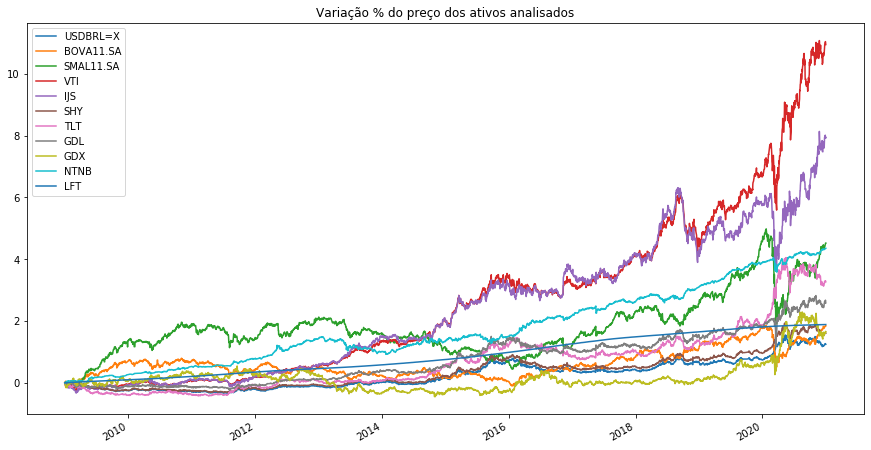

A tabela abaixo apresenta o desempenho das estratégias avaliadas em janelas móveis de 5 e 10 anos. O portfólio "Golden Butterfly Brasil" perde em todas as comparações. **O "Golden Butterfly BR+US" ganha em 6 das 8 janelas moveis de 5 anos e em todas as janelas de 10 anos.**

|  | 5yr Golden Butterfly Brasil | 5yr Golden Butterfly BR+US | 5yr Miner Butterfly BR+US | 10yr Golden Butterfly Brasil | 10yr Golden Butterfly BR+US | 10yr Miner Butterfly BR+US |
| --- | --- | --- | --- | --- | --- | --- |
| 2009 | 74.20% | 76.82% | 67.09% | 212.72% | 256.18% | 235.88% |
| 2010 | 29.00% | 82.12% | 67.42% | 175.29% | 300.38% | 283.97% |
| 2011 | 24.38% | 109.04% | 81.39% | 188.27% | 390.22% | 367.74% |
| 2012 | 47.54% | 96.35% | 79.07% | nan% | nan% | nan% |
| 2013 | 51.65% | 93.72% | 80.47% | nan% | nan% | nan% |
| 2014 | 79.52% | 101.44% | 101.02% | nan% | nan% | nan% |
| 2015 | 113.41% | 119.85% | 129.34% | nan% | nan% | nan% |
| 2016 | 131.76% | 134.51% | 157.86% | nan% | nan% | nan% |
| Média | 68.93% | 101.73% | 95.46% | 192.09% | 315.59% | 295.86% |

No entando, se for considerado o período de 2009 a 2020, as rentabilidades do "Golden Butterfly BR+US" e "Miner Butterfly BR+US" diferem marginalmente.

|  | All Golden Butterfly Brasil | All Golden Butterfly BR+US | All Miner Butterfly BR+US |
| --- | --- | --- | --- |
| 2009 | 343.04% | 485.33% | 482.46% |

A figura a seguir mostra a variação trimestral na quantidade de papéis de cada ativo do portfólio em relação a quantidade teórica adquirida no início da anaĺise. Movimentos de estresse no mercado interno, como o impeachment da ex-presidente Dilma Roussef em 2016 e a crise do COVID-19 foram momentos onde ativos dolarizados se valorizaram e a bolsa brasileira despencou, razão pela qual o portfólio teve um aumento significativo na quantidade de papéis nacionais.

```
[]
```

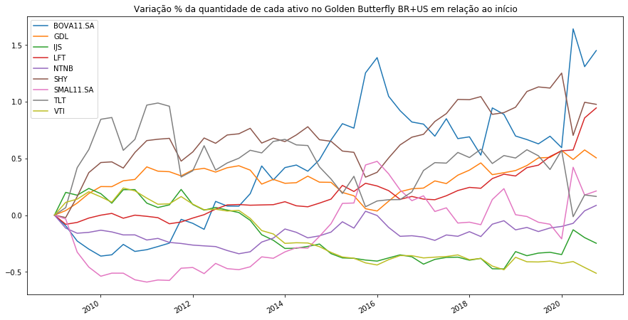

Comparando a evolução das bolsas brasileira e americana contra o Golden Butterfly BR+US (figura abaixo), percebemos que a rentabilidade do mesmo foi intermediári, porém com um comportamento com baixa volatilidade.

```
[]
```

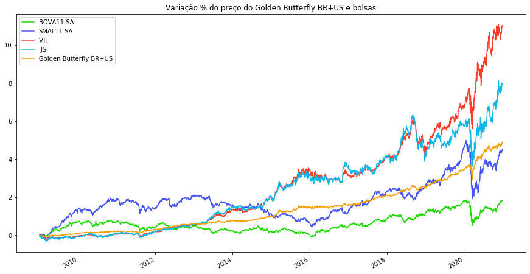

A figura a seguir apresenta o desvio padrão das diferenças diárias de cada ativo. Este indicador é uma medida razoável de volatilidade. Sob esta perspectiva, o Golden Butterfly BR+US tem volatilidade intermediária entre o Ibovespa e a NTNB.

```
[]
```

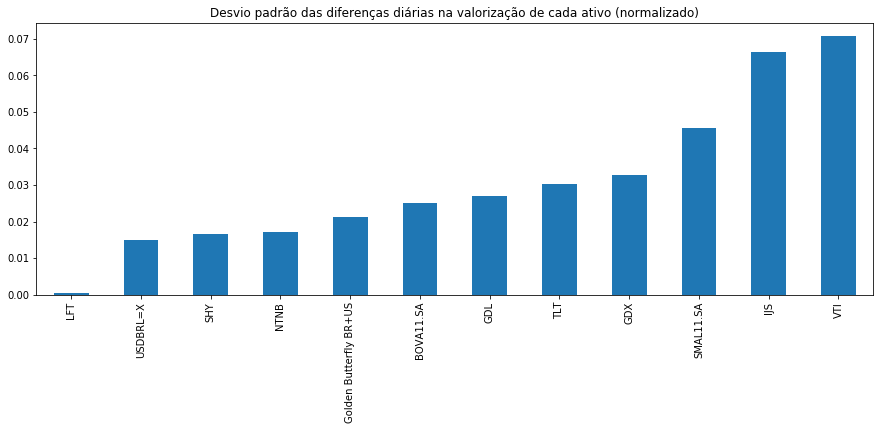

E apesar da baixa volatilidade, seu CAGR (taxa de crescimento anual composta) é a terceira mais alta entre todos os ativos considerados.

```
[]
```

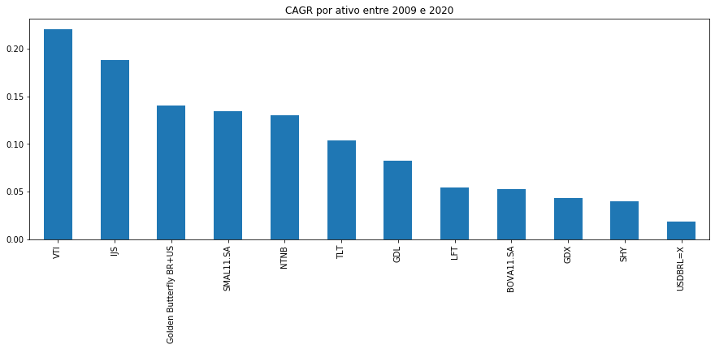

Em resumo, conclui-se que no período analisado uma estratégia de alocação em multiclasse de ativos, diversificada entre Brasil e EUA e com rebalanceamento trimestral apresentou rentabilidade superior a maior parte dos ativos individuais do portfólio e com baixa volatilidade (comportamento *bond-like* ).